# Analiza sytuacji w Polsce w wybranych zagadnieniach

Julia Drwęska-Michalska, Jakub Sawczuk

26-05-2020

## Wstęp

W poniższym projekcie przedstawiamy poziom wynagrodzeń, współczynnik skolaryzacji oraz sytuację matrymonialną i kolerację między nimi. Wszystkie przedstawione poniżej dane dotyczączą roku 2018.

## Ludność w Polsce

Bilanse liczby i struktury ludności w gminach imiennie opracowane w oparciu o wyniki Narodowych Spisów Powszechnych z uwzględnieniem zmian spowodowanych ruchem naturalnym (urodzenia i zgony), migracjami ludności (na pobyt stały i czasowy) oraz przemieszczeniami związanymi ze zmianami administracyjnymi.

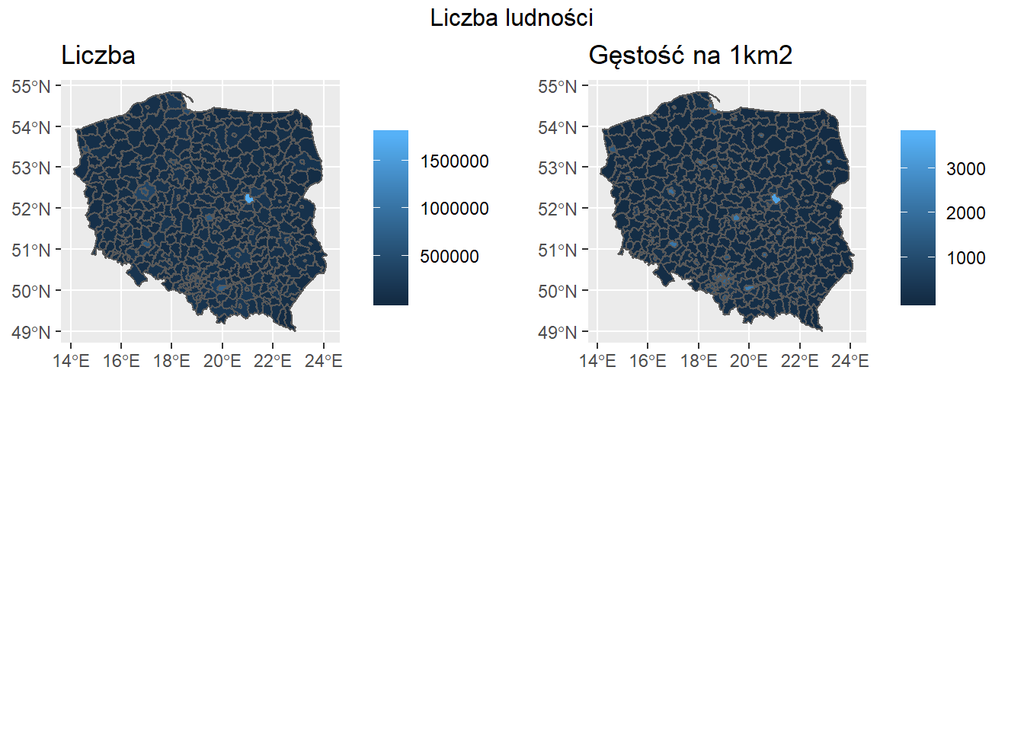

Na zestawieniu poniżej powiaty z największą liczbą ludności oraz powiaty z największą gęstością zaludnienia. Widać, że są to miasta. Co ciekawe liczba ludności nie koniecznie wskazuje nam na gęstość zaludnienia w danym powiecie.

```
##  [1] "             powiat Liczba.ludności                     powiat."
##  [2] "1   powiat Warszawa         1777972       powiat Świętochłowice"
##  [3] "2     powiat Kraków          771069             powiat Warszawa"
##  [4] "3       powiat Łódź          685285              powiat Chorzów"
##  [5] "4    powiat Wrocław          640648            powiat Białystok"
##  [6] "5     powiat Poznań          536438 powiat Siemianowice Śląskie"
##  [7] "6     powiat Gdańsk          466631              powiat Siedlce"
##  [8] "7   powiat Szczecin          402465                powiat Bytom"
##  [9] "8  powiat poznański          390308               powiat Kraków"
## [10] "9  powiat Bydgoszcz          350178                 powiat Łódź"
## [11] "10    powiat Lublin          339682               powiat Lublin"
## [12] "   Gęstość.zaludnienia"
## [13] "1                 3757"
## [14] "2                 3437"
## [15] "3                 3262"
## [16] "4                 2913"
## [17] "5                 2633"
## [18] "6                 2444"
## [19] "7                 2402"
## [20] "8                 2359"
## [21] "9                 2337"
## [22] "10                2303"
```

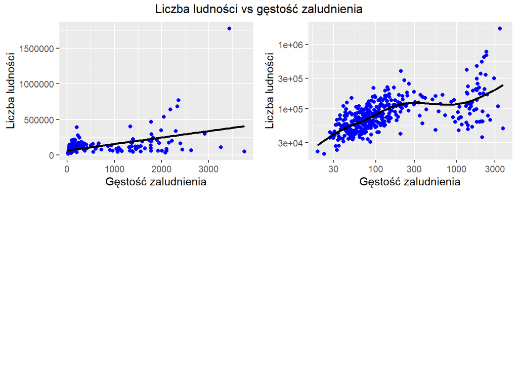

## Małżeństwa oraz rozwody w Polsce

Dane dotyczące “małżeństw zawartych w ciągu roku na 1000 ludności” opracowane są według miejsca zameldowania męża przed ślubem, w przypadku gdy mąż przed ślubem mieszkał za granicą przyjmuje się miejsce zameldowania żony przed ślubem. Wskaźniki odnoszące się do liczby i struktury ludności (płeć, grupy wieku) od 2010 roku zostały przeliczone zgodnie z bilansem przygotowanym w oparciu o wyniki NSP 2011.

GUS publikuje dane o rozwodach według miejsca zamieszkania osoby wnoszącej powództwo o rozwód. Źródłem informacji o rozwodach jest dla GUS sprawozdawczość sądów powszechnych w postaci formularzy statystycznych “Karta statystyczna dotycząca prawomocnego orzeczenia rozwodu”. W podziale terytorialnym (miasto/wieś, regiony, województwa, podregiony, powiaty) nie uwzględnia się rozwodów, w których w momencie wniesienia powództwa obie strony zamieszkiwały za granicą, dane te prezentowane są tylko dla Polski ogółem. Dane o rozwodach według miejsca zamieszkania osoby wnoszącej powództwo o rozwód. Wskaźniki odnoszące się do liczby i struktury ludności (płeć, grupy wieku) od 2010 roku zostały przeliczone zgodnie z bilansem przygotowanym w oparciu o wyniki NSP 2011.

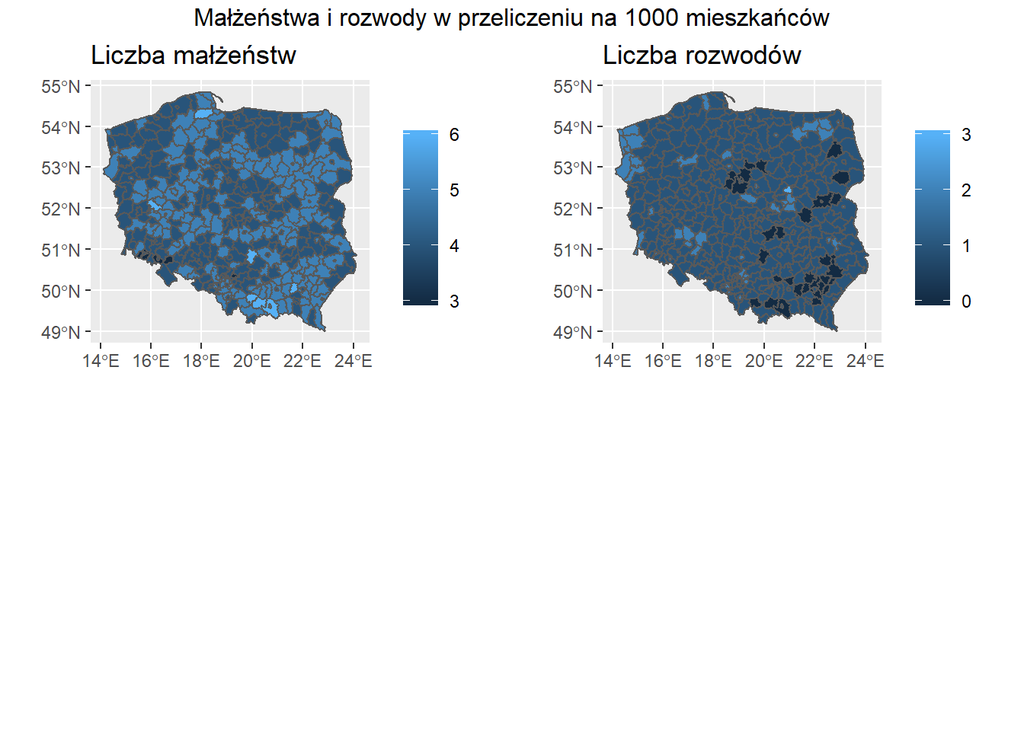

Widzimy, że liczba małżeństw oraz liczba rozwodów nie pokrywają się ze sobą.

```
## # A tibble: 182 x 2
##    powiat                        `Liczba małżeństw`
##    <fct>                                      <int>
##  1 powiat ropczycko-sędziszowski                  6
##  2 powiat włoszczowski                            6
##  3 powiat kartuski                                6
##  4 powiat nowosądecki                             6
##  5 powiat limanowski                              6
##  6 powiat myślenicki                              6
##  7 powiat wolsztyński                             6
##  8 powiat radomski                                5
##  9 powiat sierpecki                               5
## 10 powiat łukowski                                5
## # ... with 172 more rows
```

```
## # A tibble: 55 x 2
##    `powiat `           `Liczba rozwodów`
##    <fct>                           <int>
##  1 powiat legionowski                  3
##  2 powiat piaseczyński                 2
##  3 powiat Chełm                        2
##  4 powiat żyrardowski                  2
##  5 powiat Leszno                       2
##  6 powiat Łomża                        2
##  7 powiat Wrocław                      2
##  8 powiat giżycki                      2
##  9 powiat mrągowski                    2
## 10 powiat Sosnowiec                    2
## # ... with 45 more rows
```

Wydawać by się mogło, że wraz ze wzrostem liczby małżeństw powinna rosnąć liczba rozwodow. Jednak wykres temu przeczy:

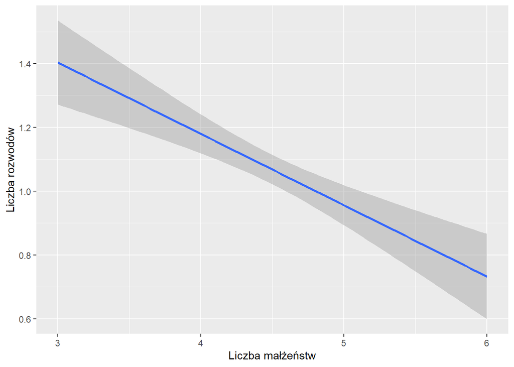

Współczynnik rozwodów wskazuje, że prawie 25% małżeństw się rozpada:

```
## # A tibble: 1 x 1
##   wspolczynnik_rozwodow
##                   <dbl>
## 1                 0.246
```

## Wynagrodzenia

Dane o wynagrodzeniach podaje się w ujęciu brutto, tj. łącznie z zaliczkami na poczet podatku dochodowego od osób fizycznych oraz od 1999 r. ze składkami na obowiązkowe ubezpieczenia społeczne (emerytalne, rentowe i chorobowe) płaconymi przez ubezpieczonego pracownika. Dane o świadczeniach społecznych podaje się w ujęciu brutto, tj. łącznie z zaliczkami na poczet podatku dochodowego od osób fizycznych.

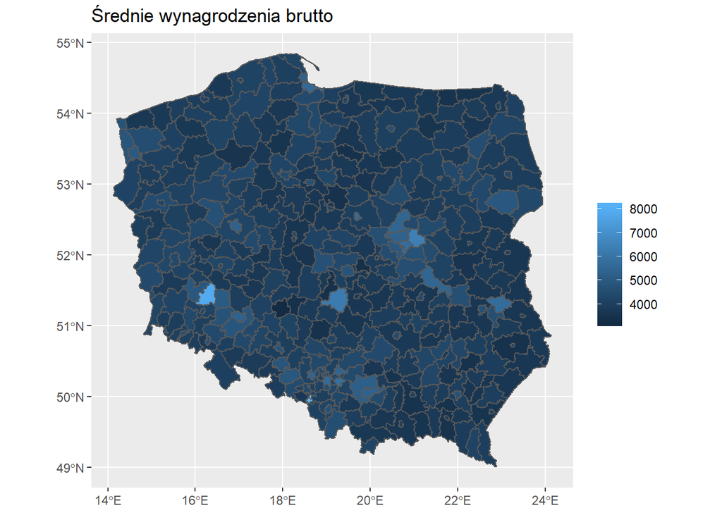

Poniżej lista powiatów z najwyższym średnim wynagrodzeniem. Co może dziwić, na pierwszym miescu Jastrzębie-Zdrój. Pierwsze miejsca zajmują powiaty na terenie których znajdują się kopalnie lub elektrownie.

```
## # A tibble: 10 x 2
##    powiat                  `Średnie wynagrodzenie`
##    <fct>                                     <dbl>
##  1 powiat Jastrzębie-Zdrój                   8121.
##  2 powiat lubiński                           7915.
##  3 powiat Warszawa                           6433.
##  4 powiat bełchatowski                       6259.
##  5 powiat Jaworzno                           5848.
##  6 powiat łęczyński                          5772.
##  7 powiat pruszkowski                        5757.
##  8 powiat Płock                              5705.
##  9 powiat Sopot                              5701.
## 10 powiat Katowice                           5699.
```

## Skolaryzacja

Szkoły podstawowe i gimnazja mogą być tylko publiczne lub niepubliczne o uprawnieniach szkół publicznych, jeżeli realizują minimum programowe oraz stosują zasady klasyfikowania i promowania uczniów ustalone przez ministra właściwego do spraw oświaty i wychowania, umożliwiające uzyskanie świadectw lub dyplomów państwowych. Obowiązek szkolny spełnia się przez uczęszczanie do szkoły podstawowej oraz gimnazjum.

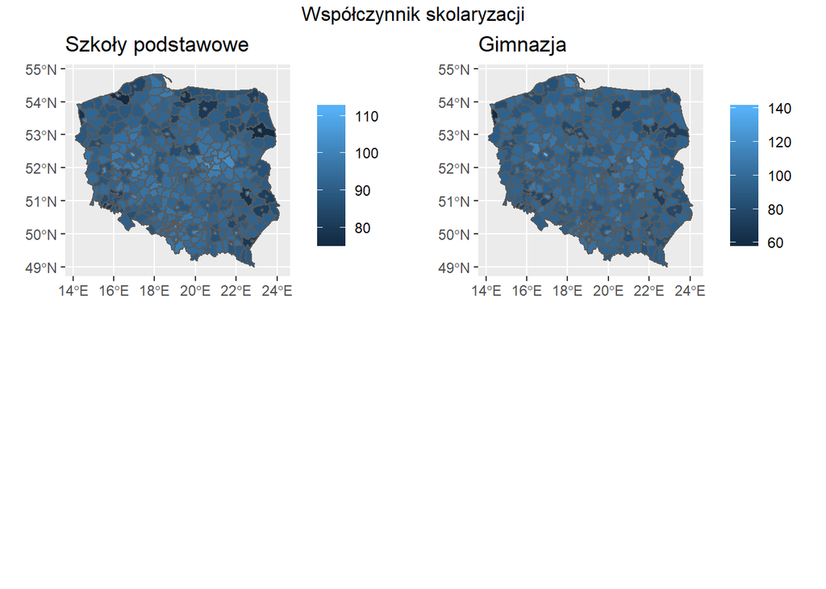

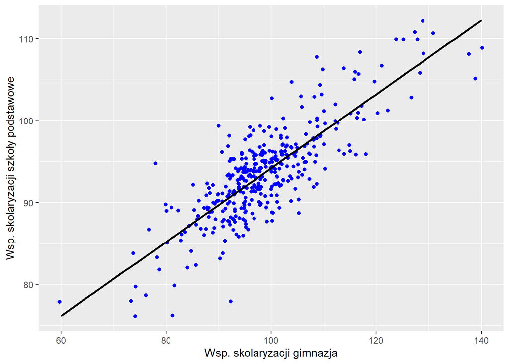

## Model pokazujący zależność rozwodów od pozostałych czynników

Poniższy model pokazuje, że liczba rozwodów jest silnie skorelowana z małżeństwami i szkołami podstawowymi (7 - 13 lat), w mniejszym stopniu z wynagrodzeniem. Jest natomiast zupełnie niezależna od gimnazjów (13 - 16 lat) oraz liczby ludności.

```
##
## Call:
## NULL
##
## Deviance Residuals:
##      Min        1Q    Median        3Q       Max
## -1.19363  -0.21007  -0.00955   0.15374   1.64533
##
## Coefficients:
##                                    Estimate Std. Error t value Pr(>|t|)
## (Intercept)                      -3.214e-01  4.755e-01  -0.676 0.499451
## wynagrodzenia_ogolem              1.279e-04  4.530e-05   2.824 0.005003
## malzenstwa_ogolem                -1.806e-01  4.034e-02  -4.477 1.01e-05
## `\\`brutto szkoły podstawowe\\``  1.348e-01  3.201e-02   4.212 3.17e-05
## `\\`brutto gimnazja\\``          -3.669e-03  4.946e-03  -0.742 0.458760
## `\\`netto szkoły podstawowe\\``  -1.114e-01  3.328e-02  -3.346 0.000902
## `\\`netto gimnazja\\``           -4.466e-03  6.337e-03  -0.705 0.481439
## ludnosc_ogolem                    1.060e-08  2.165e-07   0.049 0.960981
## gestosc_ogolem                    8.123e-05  4.621e-05   1.758 0.079634
##
## (Intercept)
## wynagrodzenia_ogolem             **
## malzenstwa_ogolem                ***
## `\\`brutto szkoły podstawowe\\`` ***
## `\\`brutto gimnazja\\``
## `\\`netto szkoły podstawowe\\``  ***
## `\\`netto gimnazja\\``
## ludnosc_ogolem
## gestosc_ogolem                   .
## ---
## Signif. codes:  0 '***' 0.001 '**' 0.01 '*' 0.05 '.' 0.1 ' ' 1
##
## (Dispersion parameter for gaussian family taken to be 0.1694228)
##
##     Null deviance: 85.082  on 379  degrees of freedom
## Residual deviance: 62.856  on 371  degrees of freedom
## AIC: 414.65
##
## Number of Fisher Scoring iterations: 2
```